# S&DS 238 Compiled Work

Kelly Farley

12/17/2020

```r
library(MASS)
library(rjags)
```

# S&DS 238: Probability, Statistics, and Data Analysis

## Course Description

Fundamental principles and techniques of probabilistic thinking, statistical modeling, and data analysis. Essentials of probability, including conditional probability, random variables, distributions, law of large numbers, central limit theorem, and Markov chains. Statistical inference with emphasis on the Bayesian approach: parameter estimation, likelihood, prior and posterior distributions, Bayesian inference using Markov chain Monte Carlo. Introduction to regression and linear models. Computers are used for calculations, simulations, and analysis of data.

## Key Skills

- **Probabilistic Thinking**: beta, binomial, Cauchy, exponential, gamma, geometric, normal, uniform distributions; conditional probability; joint and marginal distributions; indicator trick; LOTUS; law of large numbers and Markov inequality; central limit theorem and convolutions; correlation, covariance, variance
- **Bayesian Inference**: choosing appropriate priors and models; determining and analyzing posterior distribution; likelihood and maximum likelihood estimator
- **Markov Chain Monte Carlo**: theoretical basis; coding basis from scratch; use of JAGS package; random walk and Metropolis-Hastings approaches
- **Model Selection**: regression and linear models; regression effect and regression fallacy; Gibbs sampler; deviance and DIC
- **Computation**: R used for all calculations, simulations, and analysis. Emphasis on well-annotated and concise code and explanations using Latex

## Coding Samples

This course included 10 weekly problem sets, with a total of over 5k lines of Rmarkdown. Below are samples that showcase transferrable skillsets.

1. **One-Way Analysis of Variance**

A dataset containing the ages of death for novelists, poets, and nonfiction writers was analyzed to assess the hypothesis that poets tend to die young.

2. **One-Way Analysis of Variance** (JAGS)

To show the power of using JAGS, the sample analysis of the novelist, poet, and nonfiction writer ages of death was repeated using JAGS.

3. **COVID-19 Test Sensitivity** (JAGS)

COVID-19 test sensitivity is estimaated as a function of days since infection; the highest possible test sensitivity is determined.

4. **Heart Attack Percentage Reduction** (JAGS)

The percentage reduction in the rate of heart attacks due to a drug is examined and used to validate the results reported in a medical study.

5. **Mediation and Sunscreen Use** (JAGS)

It is examined whether a factual leaflet increases the likelihood that people plan to use sunscreen on a beach vacation. Furthermore, it is examined if this effect is due to the mediator variable of how likely people think they are to get skin cancer.

6. **Bayesian A/B Website Testing**

The amount of visitors that signed up for membership after viewing one version of the webpage is compared to that of visitors who viewed an alternative version of the website to determine which one is better.

7. **Game Strategy Test**

The hypothesis that alternating between the two unfair games can result in gains in the long-run is tested.

### One-Way Analysis of Variance

A dataset containing the ages of death for novelists, poets, and nonfiction writers was analyzed to assess the hypothesis that poets tend to die young.

```r
#read data
d <- read.csv("http://www.stat.yale.edu/~jtc5/238/data/cost-of-the-muse.csv")
# subset by type
poets <- d[d$Type=="Poems",]
novels <- d[d$Type=="Novels",]
nonf <- d[d$Type=="Nonfiction",]

# 10k samples
nit <- 10000

# theta matrix for 6  parameters
ths <- matrix(0, nrow=nit, ncol=6)

# first theta
th <- c(mean(d$Age), mean(d$Age), mean(d$Age), sd(d$Age), sd(d$Age), sd(d$Age))
ths[1,] <- th

# likelihood
lik <- function(th){
  mu1 <- th[1]; mu2 <- th[2]; mu3 <- th[3]; sig1 <- th[4]; sig2 <- th[5]; sig3 <- th[6]
  prod(dnorm(x=novels$Age, mean=mu1, sd=sig1)) * prod(dnorm(x=poets$Age, mean=mu2, sd=sig2)) * prod(dnorm(x=nonf$Age, mean=mu3, sd=sig3))
}

# prior
prior <- function(th){
  # assume uniform prior
  dunif(th, 0, 100)
}

# posterior
post <- function(th){
  # candidates inside interval
  if(th[1:3] > 0 && th[1:3] < 100 && th[4:6] >0){return(prior(th) * lik(th))}
  # candidates outside interval
  return(0)
}

for(i in 2:nit){
  # propose candidate
  cand <- th + runif(n=6, min=-1, max=1)
  # test ratio
  ratio <- post(cand)/post(th)
  u <- rep(runif(n=1, min=0, max=1), 6)
  test <- u < ratio
  if(sum(test==TRUE)==6){th <- cand}
  #  u <- runif(n=6, min=-1, max=1)
  # if(u < ratio){th <- cand}
  ths[i,] <- th
}

# novelists versus poets
nminusp <- ths[,1] - ths[,2]
print("Difference in age between novelists and poets")
```

```
## [1] "Difference in age between novelists and poets"
```

```r
print(quantile(nminusp, c(.025, .975)))
```

```
##       2.5%      97.5%
##  0.8117449 15.6725683
```

```r
# nonfiction versus poets
nfminusp <- ths[,3] - ths[,2]
print("Difference in age between nonfiction and poets")
```

```
## [1] "Difference in age between nonfiction and poets"
```

```r
print(quantile(nfminusp, c(.025, .975)))
```

```
##      2.5%     97.5%
##  4.059387 22.334141
```

Because the 95% confidence intervals do not include 0 and are positive, it does seem like poets die at younger ages than both novelists and nonfiction writers.

```r
# initialize new column for order
ths <- as.data.frame(ths)
ths$order <- rep(NA, nit)

# first number: group with min age
# last number: group with max age
for(i in 1:nit){
  minAge <- which.min(ths[i, c(1:3)])
  maxAge <- which.max(ths[i, c(1:3)])
  ths$order[i] <- as.numeric(paste(minAge, maxAge, sep=""))
}

# 1 = novelists, 2 = poets, 3 = nonfiction
ageOrder <- sort(table(ths$order), decreasing=TRUE)

# poets < novelists < nonfiction: 213
ageOrder[[1]]/nit
```

```
## [1] 0.9158
```

```r
# poets < nonfiction < novelists: 231
ageOrder[[2]]/nit
```

```
## [1] 0.0674
```

```r
# novelists < poets < nonfiction: 123
ageOrder[[3]]/nit
```

```
## [1] 0.0159
```

### One-Way Analysis of Variance (JAGS)

To show the power of using JAGS, the sample analysis of the novelist, poet, and nonfiction writer ages of death was repeated using JAGS.

```r
# model
mymodel <- "
model{
  for(i in 1:length(x1)){
    x1[i] ~ dnorm(mu1, 1/sig1^2)
  }
  for(i in 1:length(x2)){
    x2[i] ~ dnorm(mu2, 1/sig2^2)
  }
  for(i in 1:length(x3)){
    x3[i] ~ dnorm(mu3, 1/sig3^2)
  }
  mu1 ~ dunif(0, 100)
  mu2 ~ dunif(0, 100)
  mu3 ~ dunif(0, 100)
  sig1 ~ dunif(0, 100)
  sig2 ~ dunif(0, 100)
  sig3 ~ dunif(0, 100)
}
"

# compile
jm <- jags.model(textConnection(mymodel), data = list(x1=novels$Age, x2=poets$Age, x3=nonf$Age))
# MCMC
cs <- coda.samples(jm, variable.names = c("mu1", "mu2", "mu3", "sig1", "sig2", "sig3"), n.iter = nit)

# dataframe of results
s <- as.data.frame(cs[[1]])

# novelists versus poets
nminusp <- s[,1] - s[,2]
print("Difference in age between novelists and poets")
```

```
## [1] "Difference in age between novelists and poets"
```

```r
print(quantile(nminusp, c(.025, .975)))
```

```
##      2.5%     97.5%
##  1.129464 15.460246
```

```r
# nonfiction versus poets
nfminusp <- s[,3] - s[,2]
print("Difference in age between nonfiction and poets")
```

```
## [1] "Difference in age between nonfiction and poets"
```

```r
print(quantile(nfminusp, c(.025, .975)))
```

```
##      2.5%     97.5%
##  4.825545 22.241010
```

```r
# initialize new column for order
s$order <- rep(NA, nit)

# first number: group with min age
# last number: group with max age
for(i in 1:nit){
  minAge <- which.min(s[i, c(1:3)])
  maxAge <- which.max(s[i, c(1:3)])
  s$order[i] <- as.numeric(paste(minAge, maxAge, sep=""))
}

# 1 = novelists, 2 = poets, 3 = nonfiction
ageOrder <- sort(table(s$order), decreasing=TRUE)

# poets < novelists < nonfiction: 213
print("Probability that average age of death is poets < novelists < nonfiction")
```

```
## [1] "Probability that average age of death is poets < novelists < nonfiction"
```

```r
print(ageOrder[[1]]/nit)
```

```
## [1] 0.9258
```

```r
# poets < nonfiction < novelists: 231
print("Probability that average age of death is poets < nonfiction < novelists")
```

```
## [1] "Probability that average age of death is poets < nonfiction < novelists"
```

```r
ageOrder[[2]]/nit
```

```
## [1] 0.0626
```

```r
# novelists < poets < nonfiction: 123
print("Probability that average age of death is novelists < poets < nonfiction")
```

```
## [1] "Probability that average age of death is novelists < poets < nonfiction"
```

```r
ageOrder[[3]]/nit
```

```
## [1] 0.0101
```

These conclusions are very similar to those from the hard-coded model that did not rely on JAGS.

### COVID-19 Test Sensitivity (JAGS)

This dataset is of 1425 COVID-19 tests performed on people later confirmed to be infected with COVID-19. It is organized by t, the number of days after suspected infection when the test was administered, and includes n, the amount of people who had a test t days after infection, and x, the number of tests (of the n tests done at infection age t) that were positive.

The goal is to use this information to estimate test sensitivity as a function of days since infection. After double checking the trace plots and histograms for expected behavior (hidden for the sake of concision), the credible intervals for sensitivty at 3, 5, and 10 days after infection can be determined.

The below models are assumed:

Xt ~ Binom(nt, pt)

$Pt = logistic(\alpha - \beta(log(t) - \gamma)^2 + \delta(log(t) - \gamma)^3)$

Priors are assumed to be spread out normal distributions with mean 0 and precision 0.0001.

```r
# read in data
dat <- read.csv("http://www.stat.yale.edu/~jtc5/data/kucirka.csv")

# calculated column for ratio x/n
dat$ratio <- dat$x / dat$n

# dbin(p, n) used to determine x value
# ilogit (inverse of the logit function) used to model logistic function
# note the need to convert to log base 10; JAGS assumes log is in base e
# dnorm(mean, precision) used for normal priors
mymod <- "
  model{
    for(i in 1:length(x)){
      x[i] ~ dbin(ilogit(a - b*(log(t[i])/log(10) - c)^2 + d*(log(t[i])/log(10) - c)^3), n[i])
    }
    a ~ dnorm(0, .0001)
    b ~ dnorm(0, .0001)
    c ~ dnorm(0, .0001)
    d ~ dnorm(0, .0001)
  }
"

# for deviance
load.module("dic")
```

```
## module dic loaded
```

```r
jm <- jags.model(textConnection(mymod),
                 data=list(x=dat$x, n=dat$n, t=dat$t))
update(jm, 100000) # update for good behavior
cs <- coda.samples(jm, c("a","b","c", "d", "deviance"), 100000) # run enough times for good behavior
s <- as.data.frame(cs[[1]])
```

```r
# traceplots
plot(s$a[90000:100000], ylab="Alpha")
plot(s$b[90000:100000], ylab="Beta")
plot(s$c[90000:100000], ylab="Gamma")
plot(s$d[90000:100000], ylab="Delta")
plot(s$deviance[90000:100000], ylab="Deviance")

# histograms
truehist(s$a, xlab="Alpha")
truehist(s$b, xlab="Beta")
truehist(s$c, xlab="Gamma")
truehist(s$d, xlab="Delta")
truehist(s$deviance, xlab="Deviance")
```

```r
# 10th and 90th percentiles
arange <- quantile(s[,1], c(.1, .9))
brange <- quantile(s[,2], c(.1, .9))
crange <- quantile(s[,3], c(.1, .9))
drange <- quantile(s[,4], c(.1, .9))
# can plug these values into logistic function wtih different variable for t

# logistic function
logistic <- function(x){
  1/(1+exp(-x))
}

# function for credible interval
# input is day t
credI <- function(t){
  b10 <- logistic(arange[[1]]-brange[[1]]*(log10(t)-crange[[1]])^2 +
                    drange[[1]]*(log10(t)-crange[[1]])^3) # 10th percentile
  b90 <- logistic(arange[[2]]-brange[[2]]*(log10(t)-crange[[2]])^2 +
                    drange[[2]]*(log10(t)-crange[[1]])^3) # 90th percentile
  print(paste("The 80% credible interval for sensitivity at day", t, "is:",
              round(min(b10, b90), 4), round(max(b10, b90), 4)))
}

credI(3) # t=3
```

```
## [1] "The 80% credible interval for sensitivity at day 3 is: 0.0119 0.2636"
```

```r
credI(5) # t=5
```

```
## [1] "The 80% credible interval for sensitivity at day 5 is: 0.5826 0.7111"
```

```r
credI(10) # t=10
```

```
## [1] "The 80% credible interval for sensitivity at day 10 is: 0.6971 0.8215"
```

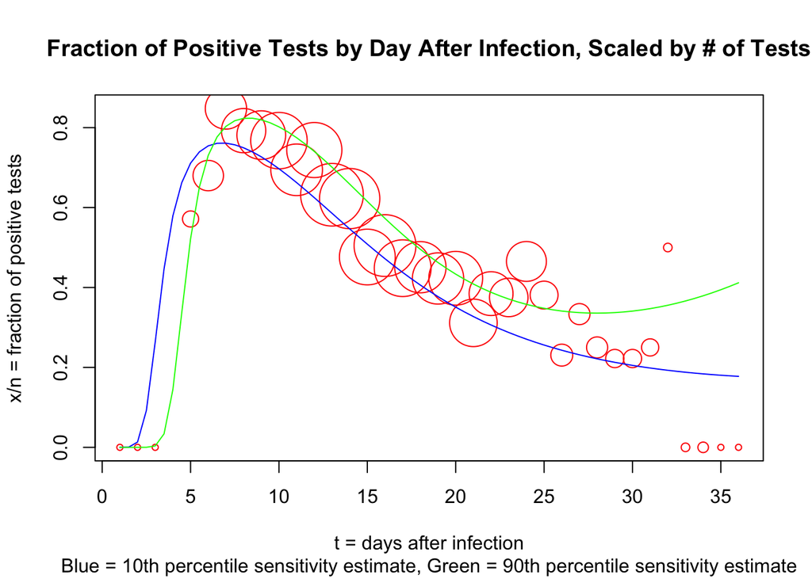

```r
# infection ages 1-36
tvals <- seq(1, 36, by=.5)
ten <- logistic(arange[[1]]-brange[[1]]*(log10(tvals)-crange[[1]])^2 +
                  drange[[1]]*(log10(tvals)-crange[[1]])^3) # 10th percentile sensitivity at each infection age
ninety <- logistic(arange[[2]]-brange[[2]]*(log10(tvals)-crange[[2]])^2 +
                     drange[[2]]*(log10(tvals)-crange[[2]])^3) # 90th percentile sensitivity at each infection age

# plot from 2a
plot(dat$t, dat$ratio, cex=.7*sqrt(dat$n), col="red",
     main="Fraction of Positive Tests by Day After Infection, Scaled by # of Tests",
     xlab="t = days after infection", ylab="x/n = fraction of positive tests",
     sub="Blue = 10th percentile sensitivity estimate, Green = 90th percentile sensitivity estimate")
lines(tvals, ten, col="blue") # curve for 10th percentile sensitivity
lines(tvals, ninety, col="green") # curve for 90th percentile sensitivity
```

The blue (10th percentile) and green (90th percentile) curves follow the general flow of the observed data, indicating that the JAGS model did perform as expected and outputted reasonable parameters. Knowing that the model is an appropriate fit, additional inferences can be made about the maximum test sensitivity.

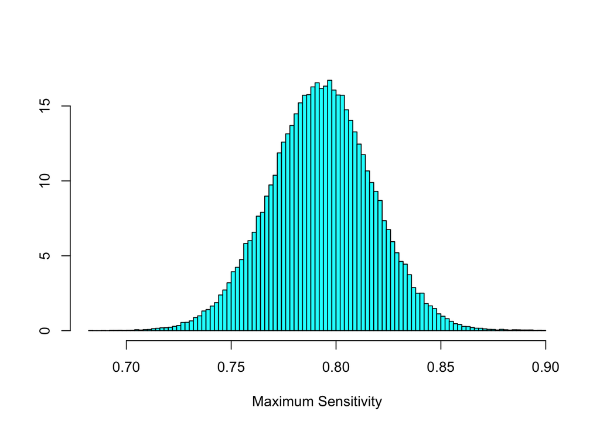

```r
# new calculated column for max sensitivty
s$maxSensitivity <- rep(NA, dim(s)[1])

# function to evaluate sensitivity at days 1-36
for(i in 1:dim(s)[1]){
  t <- seq(1, 36, by=.001) # evaluate sensitivity at days 1-36 using fine grid of .001
  # outputs sensitivity at days 1-36 using a, b, c, d values associated with this trial
  eachDaySensitivity <- logistic(s$a[i] - s$b[i]*(log10(t) - s$c[i])^2 + s$d[i]*(log10(t) - s$c[i])^3)
  s$maxSensitivity[i] <- max(eachDaySensitivity) # gives max sensitivity for this trial
  # gives max day for this trial; divide by 1000 to account for grid
  s$maxDay[i] <- which.max(eachDaySensitivity)/1000
}

# histogram for maximum sensitivity
truehist(s$maxSensitivity, xlab="Maximum Sensitivity")
```

```r
# credible interval for maximum sensitivity using quantile
print(paste("The 95% credible interval for the maximum test sensitivity is:",
            round(quantile(s$maxSensitivity, .025), 4), round(quantile(s$maxSensitivity, .975), 4)))
```

```
## [1] "The 95% credible interval for the maximum test sensitivity is: 0.7446 0.841"
```

### Heart Attack Percentage Reduction (JAGS)

A drug is thought to reduce the risk of coronary heart disease. It is given to 4081 asymptomatic middle-aged men. 2051 men receive 600 mg of the drug twice daily; 2030 men receive placebo. There are 56 heart attacks in the treatment group, and 84 heart attacks in the control group. What is the percentage reduction in the rate of heart attacks? (This analysis validated the results proposed in the Helsinki Heart Study.)

```r
# model
mymodel <- "
model{
  x1 ~ dbin(mu1, 2051)
  x2 ~ dbin(mu2, 2030)
  mu1 ~ dunif(0, 1)
  mu2 ~ dunif(0, 1)
}
"

# compile
jm <- jags.model(textConnection(mymodel), data = list(x1=56, x2=84))
# MCMC
cs <- coda.samples(jm, variable.names = c("mu1", "mu2"), n.iter = nit)

# dataframe of results
s <- as.data.frame(cs[[1]])

print("95% CI for treatment:")
```

```
## [1] "95% CI for treatment:"
```

```r
print(quantile(s[,1], c(.025, .975)))
```

```
##       2.5%      97.5%
## 0.02098641 0.03541405
```

```r
print("95% CI for control:")
```

```
## [1] "95% CI for control:"
```

```r
print(quantile(s[,2], c(.025, .975)))
```

```
##       2.5%      97.5%
## 0.03344118 0.05108701
```

```r
# new column for percent reduction
s$pRed <- ((s$mu2 - s$mu1)/s$mu2)*100
print("95% CI for percentage reduction:")
```

```
## [1] "95% CI for percentage reduction:"
```

```r
print(quantile(s[,3], c(.025, .975)))
```

```
##      2.5%     97.5%
##  7.742912 52.612793
```

This 95% CI for percentage reduction approximates that given in the paper (8.2 to 52.6).

### Mediation and Sunscreen Use (JAGS)

100 people who are planning a beach vacation are selected. Half of the group receives a leaflet with facts about skin cancer, while the other half does not. When each person arrives at the beach, they are asked 1) what they believe the likelihood that they will get skin cancer at some point in their lives and 2) whether they were planning to use sunscreen. Does the leaflet increase the likelihood that people plan to use sunscreen? If so, is any part of this effect due to how likely people think they are to get skin cancer (i.e., is it a mediator)?

```r
# read data
sb <- read.csv("/Users/kellyfarley/Desktop/Yale/Junior/5 Probability/Completed Psets/Pset 10/mediation-data_Wright-London.csv")

# model
regmod <- "model{
  for(i in 1:length(y)){
    m[i] ~ dnorm(alpham + beta1*x[i], taum)
    y[i] ~ dnorm(alphay + beta2*m[i] + beta3*x[i], tauy)
  }
  alpham ~ dnorm(0,.0001)
  alphay ~ dnorm(0,.0001)
  beta1 ~ dnorm(0,.0001)
  beta2 ~ dnorm(0,.0001)
  beta3 ~ dnorm(0,.0001)
  taum ~ dgamma(.01,.01)
  tauy ~ dgamma(.01,.01)
  sigm <- 1 / sqrt(taum)
  sigy <- 1 / sqrt(tauy)
}"

# compile
jm <- jags.model(file = textConnection(regmod), data = list(x=sb$leaflet, m=sb$likely, y=sb$plan))
# MCMC
cs <- coda.samples(jm, variable.names = c("beta1", "beta2", "beta3", "sigm", "sigy"), n.iter = 1000)

# dataframe of results
s <- as.data.frame(cs[[1]])

# mediation proportion
s$mp <- s$beta1 * s$beta2 / (s$beta1 * s$beta2 + s$beta3)

# posterior mean
mean(s$mp)
```

```
## [1] 0.4078463
```

```r
# 95% CI
quantile(s$mp, c(.025, .975))
```

```
##      2.5%     97.5%
## 0.2587340 0.5604054
```

### Bayesian A/B Website Testing

There are two versions of a website home page. To determine which version is better, the website is coded such that each visitor will be shown version F or version B. During the experiment, there were 237 visitors that saw version F, 8 of whom signed up for membership; there were 215 visitors that saw version B, 11 of whom signed up for membership. Given this data, what is the probability that version B is better for signups than version F?

```r
## parameter space same for F and B: from 0 to 1, in increments of 0.001
## restructured so that all values keep 3 decimal places
fthetas <- sapply(seq(0, 1, by=0.001), format, nsmall=3)
bthetas <- fthetas
## matrix combining both thetas using paste
allthetas <- outer(fthetas, bthetas, paste)
## first 4 numbers in a cell will be fthetas; last 4 numbers in a cell will be bthetas

## uniform prior with same dimensions as allthetas
## each cell has probability 1/(1001*1001)
prior <- matrix(1/(length(fthetas)*length(fthetas)), nrow = length(fthetas), ncol = length(fthetas))

## likelihood using observed data
fliks <- dbinom(8, 237, as.numeric(fthetas))
bliks <- dbinom(11, 215, as.numeric(bthetas))

## posterior
## since F and B are independent, multiplying their likelihoods probabilities together will give the combined likelihood for a pair
## multiplication function to apply to each cell of matrix
multiplyLiks <- function(x){
  thisLik <- fliks[which(fthetas==substr(x, 1, 5))] * bliks[which(bthetas==substr(x, 7, 12))]
  return(thisLik)
}
## apply to columns and rows
allLiks <- apply(allthetas, c(1,2), multiplyLiks)

## posterior
post <- prior*allLiks/sum(prior*allLiks)

## sum matrix entries where bthetas > fthetas
## 1) loop through post matrix, 2) find corresponding value in allthetas, 3) if allthetas value meets specifications, add to sum

## initialize sum to 0
bBiggerProb <- 0

## loop thru rows
for(i in 1:dim(post)[1]){
  ## loop thru columns
  for(k in 1:dim(post)[2]){
    thisTheta <- allthetas[i, k]
    thisF <- substr(thisTheta, 1, 5)
    thisB <- substr(thisTheta, 7, 12)
    if(thisB > thisF){
      bBiggerProb <- bBiggerProb + post[i, k]
    }
  }
}

print(bBiggerProb)
```

```
## [1] 0.8112291
```

The probability that $V_B > V_F$ is approximately 0.8112291, where $V_B$ represents the probability a random probability will sign up when seeing version B and $V_F$ represents the same for version F.

### Game Strategy Test

There are two games that can be played repeatedly. In both games, you gain 1 dollar for tossing heads and lose 1 dollar for tossing tails. The games differ based on the probability for heads and tails.

For Game 1: Toss a weighted coin with P(H) = 0.495

For Game 2: If the net winning is a multiple of 3, toss coin 2a; else, toss coin 2b. Coin 2a has P(H) = 0.095, and Coin 2b has P(H) = 0.745.

Game 1 is unfair and results in more losses than gains. Game 2 is also unfair. It is proposed that alternating between the two games, however, does result in gains in the long-run. The below simulation tests this theory by performing 1k repetitions of 10k plays of the game.

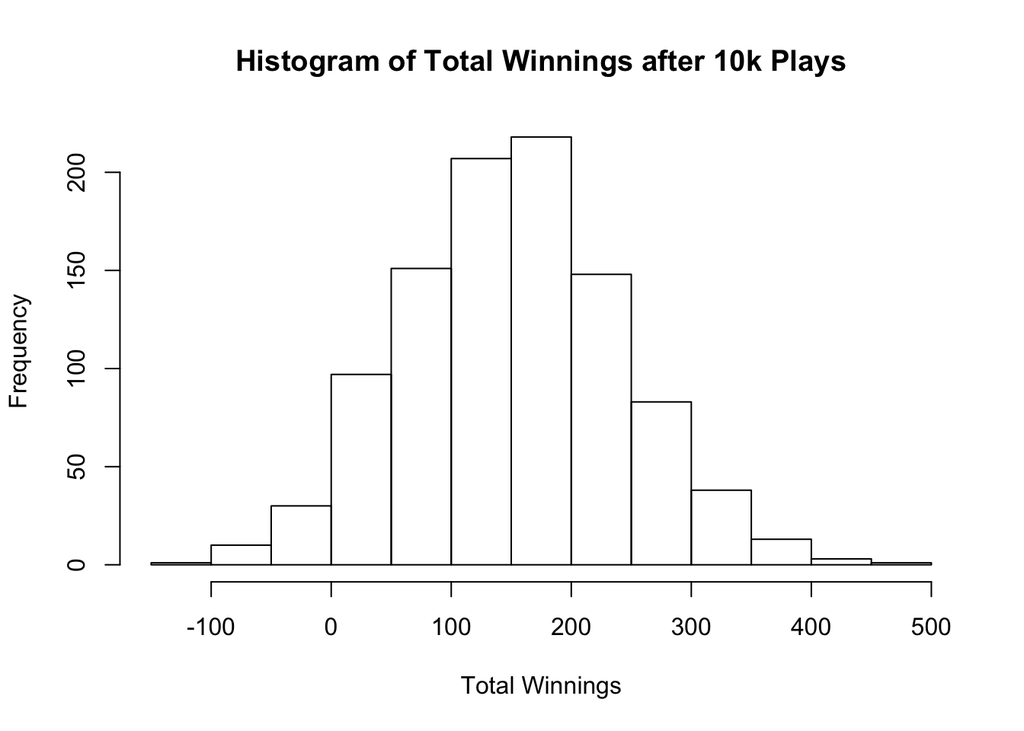

```r
# set seed
set.seed(1234)

# function to simulate mixed game
tossSim <- function(){
  nit <- 10000 # simulate 10k plays
  winVec <- rep(NA, nit) # vector to store winnings at each step
  winVec[1] <- 0 # set initial winnings to 0

  for(i in 2:nit){
    currentWinnings <- winVec[i-1] # winnings up to this point

    # choose which game
    game <- sample(c(1, 2), 1, prob=c(.5, .5))

    # game 1
    if(game==1){
      toss <- sample(c(0, 1), 1, prob=c(0.495, 0.505)) # toss will give 0=H or 1=T
    }

    # game 2
    if(game==2){
        # if winnings are multiple of 3, toss coin 2a: P(H)  = 0.095, P(T) = 0.905
        if(currentWinnings %% 3 == 0){
          toss <- sample(c(0, 1), 1, prob=c(0.095, 0.905)) # toss will give 0=H or 1=T
        } else{
          # otherwise, toss coin 2b: P(H) = 0.745, P(T) = 0.255
          toss <- sample(c(0, 1), 1, prob=c(0.745, 0.255)) # toss will give 0=H or 1=T
        }
    }

    # H gain dollar
    if(toss==0){
      winVec[i] <- currentWinnings + 1
    }

    # T lose dollar
    if(toss==1){
      winVec[i] <- currentWinnings - 1
    }
  }

  thisWin <<- winVec[nit] # will return winnings after 10k trials; stored as global variable
}

# run tossSim 1k times
nrep <- 1000

# vector for winnings at end of 10k plays
endWin <- rep(NA, nrep)

# fill vector by running tossSim
for(j in 1:nrep){
  tossSim()
  endWin[j] <- thisWin # tossSim outputs thisWin as global variable
}

# histogram
hist(endWin, xlab="Total Winnings", main="Histogram of Total Winnings after 10k Plays")
```

```r
# expected winnings
mean(endWin)
```

```
## [1] 150.898
```

```r
# probability of negative winning
sum(endWin < 0) / length(endWin)
```

```
## [1] 0.041
```